# Assignment 02 : Plotting Exercises

## Problem 01

In this problem, you will create an artificial data set using one of the NumPy random functions and present the data in a single-panel figure. You are free to decide how to implement this task, provided you meet the basic requirements below. Insightful high quality plots will receive higher marks.

### Importing Libraries

```python
import numpy as np
import matplotlib.pyplot as plt
```

### Generating Random Data

generating 300 random numbers from a normal distribution

```python
# Generate 300 random numbers from a normal distribution
data = np.random.randn(300)  # Normal distribution with mean=0 and std=1
```

### Plotting the Histogram

Using matplotlib.pyplot for plotting histogram of the generated data

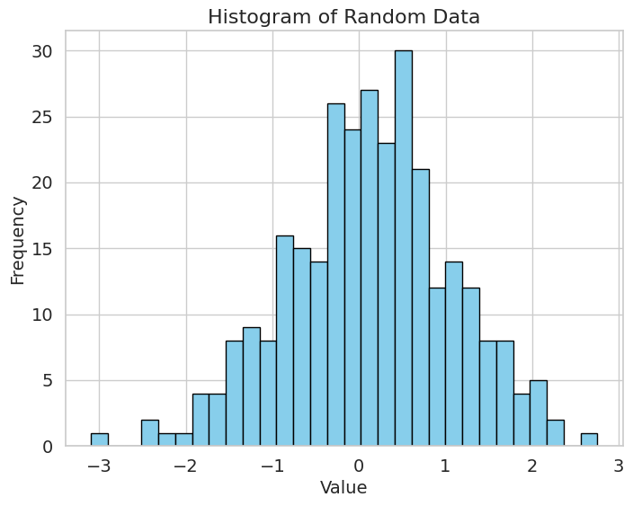

```python
# figuare size & data to show in plot
plt.figure(figsize=(8, 6))
plt.hist(data, bins=30, edgecolor='black', color='skyblue')

# title
plt.title("Histogram of Random Data", fontsize=16)

#labels for x and y axis
plt.xlabel("Value", fontsize=14)
plt.ylabel("Frequency", fontsize=14)

# font size
plt.xticks(fontsize=14)
plt.yticks(fontsize=14)

# showing histogram
plt.show()
```

### Calculating Mean and Median

using NumPy’s mean() and median() functions to calculate mean and median respectively.

```python
# calculating mean and median of the data
mean_value = np.mean(data)
median_value = np.median(data)
```

### Adding lines & Annotations for Mean and Median

using plt.axvline() to add lines for mean and median.  
using plt.text() to add annotations for mean and median.

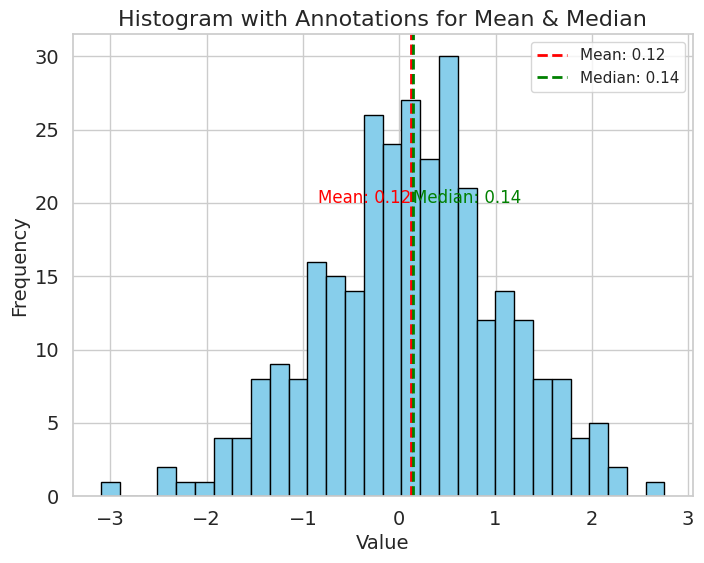

```python
# creating histogram again for mean & median
plt.figure(figsize=(8, 6))  # Set figure size
plt.hist(data, bins=30, edgecolor='black', color='skyblue')  # Create histogram with 30 bins

# adding lines for mean & median
plt.axvline(mean_value, color='red', linestyle='dashed', linewidth=2, label=f'Mean: {mean_value:.2f}')
plt.axvline(median_value, color='green', linestyle='dashed', linewidth=2, label=f'Median: {median_value:.2f}')

# annotations for mean & median
plt.text(mean_value, 20, f'Mean: {mean_value:.2f}', color='red', fontsize=12, horizontalalignment='right')
plt.text(median_value, 20, f'Median: {median_value:.2f}', color='green', fontsize=12, horizontalalignment='left')

# title
plt.title("Histogram with Annotations for Mean & Median", fontsize=16)

#labels
plt.xlabel("Value", fontsize=14)
plt.ylabel("Frequency", fontsize=14)

# legend
plt.legend()

# font size
plt.xticks(fontsize=14)
plt.yticks(fontsize=14)

# showing final plot
plt.show()
```

## Problem 02

Load data from the following parquet file into Python. Make elegant plots presenting the data as thoroughly as possible.

### Importing libraries & Loading parquet from link

```python
import pandas as pd
import seaborn as sns
import matplotlib.pyplot as plt

# Loading parquet file from URL
df = pd.read_parquet("https://star.herts.ac.uk/~kuhn/DHV/exercises_problem2.parquet")
```

### Data representation

printing dataset to check the type of data & columns

```python
# print few rows of dataset
df.head()

#summary of data
df.describe()

# data types
df.info()
```

```
<class 'pandas.core.frame.DataFrame'>
RangeIndex: 400 entries, 0 to 399
Data columns (total 4 columns):
 #   Column  Non-Null Count  Dtype
---  ------  --------------  -----
 0   var1    400 non-null    float64
 1   var2    400 non-null    float64
 2   var3    400 non-null    float64
 3   class   400 non-null    int16
dtypes: float64(3), int16(1)
memory usage: 10.3 KB
```

### Data cleaning

checking for missing values & dropping rows with missing values

```python
# Checking for missing values
print(df.isnull().sum())

# droping rows wih missing values
df = df.dropna()
```

```
var1     0
var2     0
var3     0
class    0
dtype: int64
```

```python
# figure size & style
plt.figure(figsize=(12, 10))
sns.set_theme(style="whitegrid")
```

### Histogram

Visualizes distribution of data in parquet

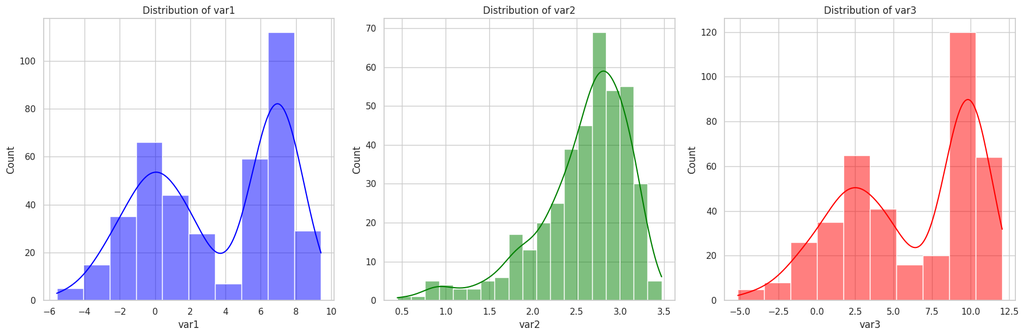

```python
# Histograms for all columns with subpplot
fig, axes = plt.subplots(1, 3, figsize=(18, 6))

# for var1
sns.histplot(df['var1'], kde=True, color='blue', ax=axes[0])
axes[0].set_title("Distribution of var1")

# for var2
sns.histplot(df['var2'], kde=True, color='green', ax=axes[1])
axes[1].set_title("Distribution of var2")

# for var3
sns.histplot(df['var3'], kde=True, color='red', ax=axes[2])
axes[2].set_title("Distribution of var3")

plt.tight_layout()
plt.show()
```

### box-plot

Displays statistics of variables by class to compare distributions across classes.

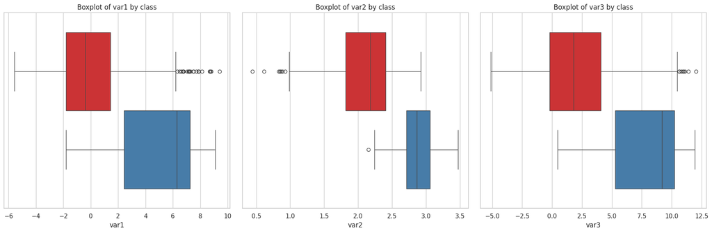

```python
# Box plot for all columns with subplot
fig, axes = plt.subplots(1, 3, figsize=(18, 6))

# for var1
sns.boxplot(x='var1', hue='class', data=df, palette='Set1', ax=axes[0], legend=False)
axes[0].set_title("Boxplot of var1 by class")

# for var2
sns.boxplot(x='var2', hue='class', data=df, palette='Set1', ax=axes[1], legend=False)
axes[1].set_title("Boxplot of var2 by class")

# for var3
sns.boxplot(x='var3', hue='class', data=df, palette='Set1', ax=axes[2], legend=False)
axes[2].set_title("Boxplot of var3 by class")

plt.tight_layout()
plt.show()
```

### Scatter plot

idenify the correlation in data from parquet

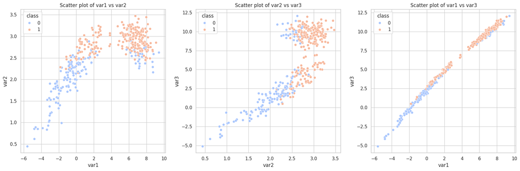

```python
# scatter plot between pairs of two columns
fig, axes = plt.subplots(1, 3, figsize=(18, 6))

# for var1 , var2
sns.scatterplot(x='var1', y='var2', hue='class', data=df, palette='coolwarm', ax=axes[0])
axes[0].set_title("Scatter plot of var1 vs var2")

# for var2 , var3
sns.scatterplot(x='var2', y='var3', hue='class', data=df, palette='coolwarm', ax=axes[1])
axes[1].set_title("Scatter plot of var2 vs var3")

# for var1 , var3
sns.scatterplot(x='var1', y='var3', hue='class', data=df, palette='coolwarm', ax=axes[2])
axes[2].set_title("Scatter plot of var1 vs var3")

plt.tight_layout()
plt.show()
```

### pair-plot

pairwise relationship between values and class

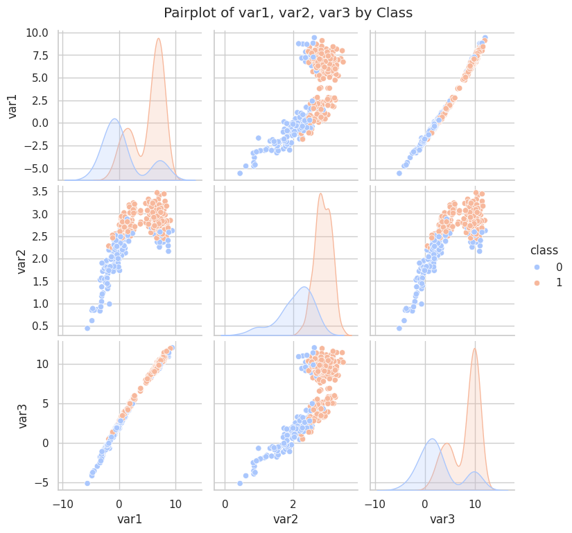

```python
# Pairplot for relationships between variables and class
sns.pairplot(df, hue='class', palette='coolwarm')
plt.suptitle("Pairplot of var1, var2, var3 by Class", y=1.02)

plt.show()
```